# Modélisation-explication-prédiction d’une série chronologique

*1.2 Stationnarisation par différenciation*

Dans l’analyse des séries temporelles, la Stationnarisation Par Différenciation est utilisée pour transformer une série temporelle non stationnaire en une série stationnaire. Dans ce contexte, la présence d’une saisonnalité de période 12 selon l’ACF (Fonction d’Auto-corrélation) souligne l’importance de la méthode de différenciation pour éliminer cette composante saisonnière. En effet, en différenciant la série temporelle d’un ordre approprié, il est possible d’atténuer ou d’éliminer la saisonnalité, permettant ainsi une analyse plus précise et l’application de modèles appropriés.

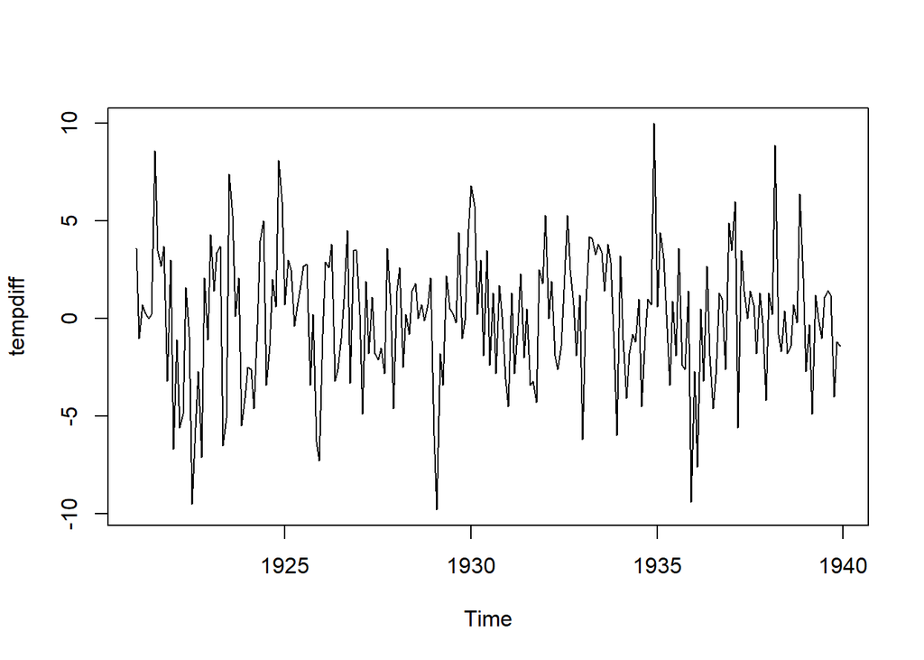

Graphiquement, la série différenciée ne comporte plus d’effet saisonnier.

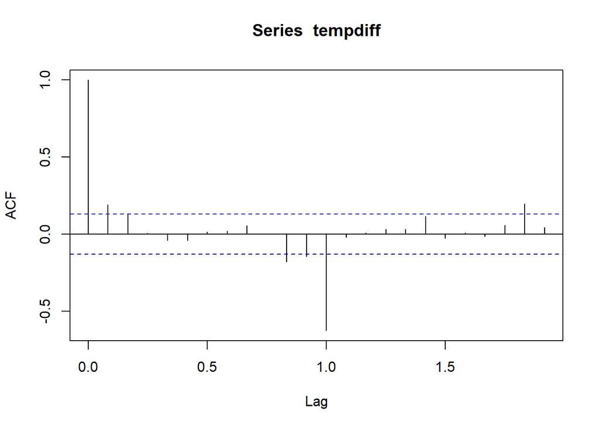

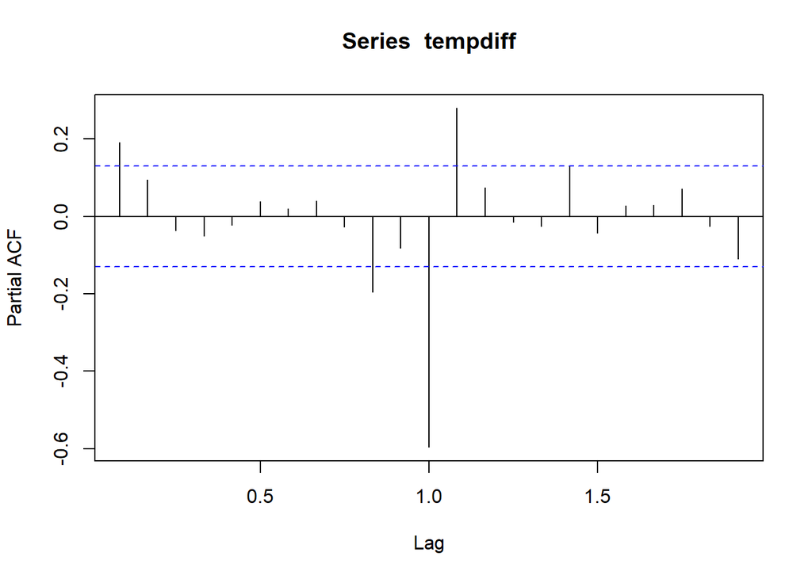

```
##
##  Augmented Dickey-Fuller Test
##
## data:  tempdiff
## Dickey-Fuller = -5.3526, Lag order = 6, p-value = 0.01
## alternative hypothesis: stationary
```

La p-valeur est inférieure au seuil, on accepte l’hypothèse de stationnarité de la série différenciée au lag 12.

**2. Identification du modèle (Modélisation du processus stationnaire)**

L’étape d’identification du modèle ARMA est essentielle dans l’analyse des séries temporelles. À cette étape, nous utilisons les fonctions d’auto-corrélation et d’auto-corrélation partielle pour explorer la structure de dépendance temporelle des données. Ces outils nous aident à identifier les ordres potentiels des processus ARMA(p, q).

Selon l’ACF de la série différenciée, si on ajustait un modèle MA, on choisirait un MA(2) ou un MA(3), c’est plus prudent de prendre un MA(q=2). Selon le PACF de la série différenciée, si on ajustait un modèle AR, on choisirait un AR (p=1).

On réalise une fonction ARMAIC ajustant le meilleur ARMA(p, q) au sens du critère de l’AIC, c’est-à-dire le meilleur modèle ayant l’AIC le plus petit.

```
## $model
##
## Call:
## arima(x = x, order = c(p, 0, q), include.mean = FALSE, optim.control = list(maxit = 600))
##
## Coefficients:
##          ma1     ma2
##       0.1708  0.1343
## s.e.  0.0653  0.0667
##
## sigma^2 estimated as 11.22:  log likelihood = -599.15,  aic = 1204.31
##
## $AIC
##          0        1        2        3
## 0 1211.196 1206.243 1204.307 1206.111
## 1 1204.670 1205.417 1206.180       NA
## 2 1204.639 1206.486       NA       NA
## 3 1206.335       NA       NA       NA
##
## $popt
## [1] 0
##
## $qopt
## [1] 2
##
## $aic
## [1] 1204.307
```

Ici, c’est le modèle ARMA(0,2) = MA(2) qui est choisi selon le critère de l’AIC. Le modèle estimé est le suivant : X_t=Z_t +0.1708Z_(t-1) + 0.1343Z_(t-2) + résidu.

**3. Diagnostic du modèle (Test d’indépendance des résidus)**

L’étape du diagnostic du modèle constitue une étape cruciale dans l’analyse des séries temporelles. À ce stade, nous évaluons la qualité et la pertinence du modèle ARMA sélectionné en examinant les résidus du modèle. Nous utilisons des techniques telles que les tests statistiques pour vérifier si les résidus présentent des comportements inattendus. Ici, on fait un test d’indépendance des résidus. L’objectif est de s’assurer que le modèle capturé est adéquat pour représenter la structure de la série temporelle et que ses prévisions sont fiables pour des applications futures. Les résidus devraient ressembler à un bruit blanc.

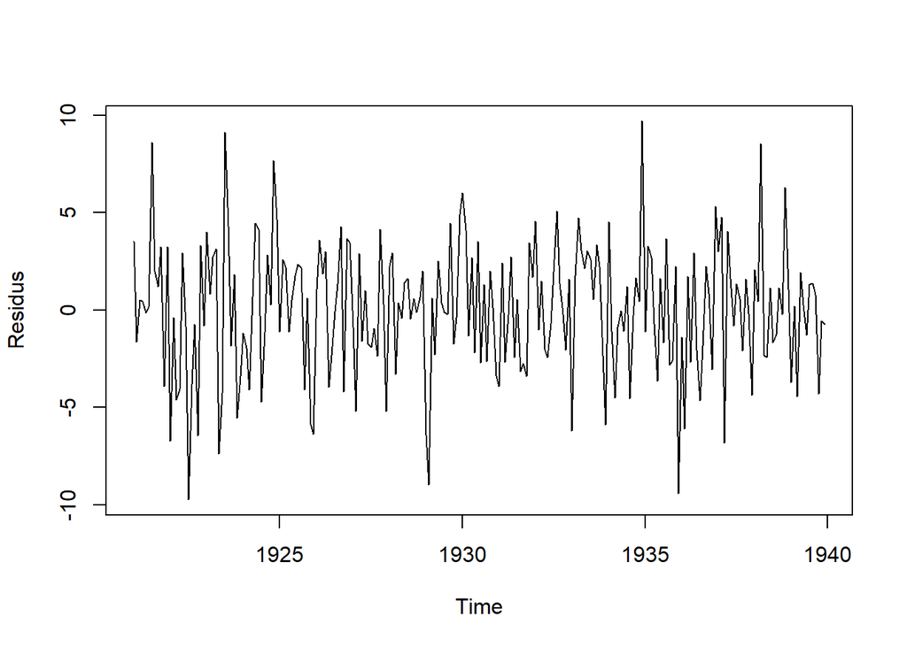

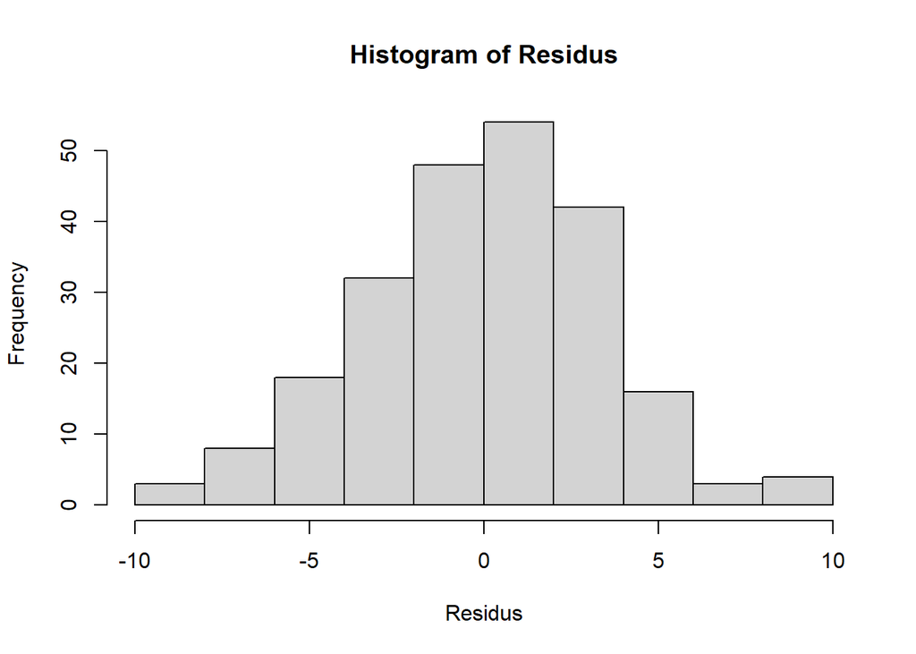

On effectue un test statistique pour vérifier si les résidus sont stationnaires et indépendants (le test de Box-Ljung au seuil de 5%). L’hypothèse nulle postule que les résidus, ou les erreurs, dans le modèle sont indépendants les uns des autres, ce qui signifie qu’il n’y a pas de relation ou de corrélation entre eux. En d’autres termes, les résidus ne suivent pas de motif ou de tendance identifiable. En revanche, l’hypothèse alternative avance que les résidus ne sont pas indépendants, ce qui suggère qu’il existe une corrélation ou une structure dans les résidus, indiquant ainsi une violation de l’indépendance des erreurs dans le modèle.

```
##
##  Box-Ljung test
##
## data:  Residus
## X-squared = 4.5136, df = 7, p-value = 0.7191
```

On trouve un p-valeur supérieur au seuil de 5%, on accepte l’hypothèse nulle et on conclut que les résidus sont bien indépendants.

**4. Prévision**

On utilise le modèle ARMA pour faire des prévisions sur des périodes futures de la série temporelle. On choisit de faire les prévisions mensuelles de la température moyenne au cours de l’année 1940.

```
##           Jan      Feb      Mar      Apr      May      Jun      Jul      Aug
## 1940 36.19883 40.44006 37.34006 48.84006 52.24006 56.84006 61.64006 63.04006
##           Sep      Oct      Nov      Dec
## 1940 59.24006 42.54006 45.24006 36.24006
```

[figure not shown]

**Validation des prévisions**

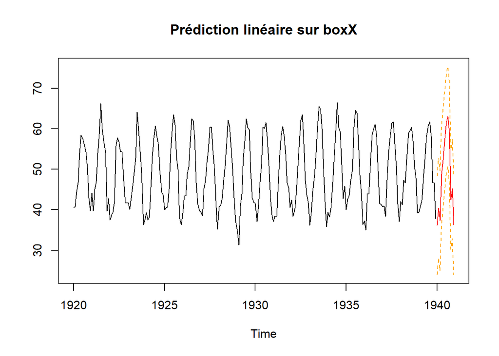